# Assignment 9: Spatial Analysis in R

Chrissie Pantoja

## OVERVIEW

This exercise accompanies the lessons in Environmental Data Analytics (ENV872L) on spatial analysis.

## Directions

1. Rename this file `<FirstLast>_A09_SpatialAnalysis.Rmd` (replacing `<FirstLast>` with your first and last name).
2. Change “Student Name” on line 3 (above) with your name.
3. Use the lesson as a guide. It contains code that can be modified to complete the assignment.
4. Work through the steps, **creating code and output** that fulfill each instruction.
5. Be sure to **answer the questions** in this assignment document. Space for your answers is provided in this document and is indicated by the “>” character. If you need a second paragraph be sure to start the first line with “>”. You should notice that the answer is highlighted in green by RStudio.
6. When you have completed the assignment, **Knit** the text and code into a single **HTML** file.

## DATA WRANGLING

### Set up your session

1. Import libraries: tidyverse, sf, leaflet, here, and mapview

```r
# Import the familiar libraries
library(tidyverse); library(lubridate); library(here)

#install.packages('sf')
library(sf)

#install.packages('leaflet')
library(leaflet)

#install.packages('mapview')
library(mapview); mapviewOptions(fgb = FALSE)

#Disable on-the-fly projections
sf::sf_use_s2(FALSE)
```

2. Execute the `here()` command to display the current project directory

```r
here()
```

```
## [1] "/Users/chrissiepantoja/Library/CloudStorage/OneDrive-DukeUniversity/PHD DUKE/1 COURSES/3 FALL SEMESTER 2024/ENV872-ENVIRONMENTAL-DATA-ANALYSIS/EDE_Fall2024"
```

### Read (and filter) county features into an sf dataframe and plot

In this exercise, we will be exploring stream gage height data in Nebraska corresponding to floods occurring there in 2019. First, we will import from the US Counties shapefile we’ve used in lab lessons, filtering it this time for just Nebraska counties. Nebraska’s state FIPS code is `31` (as North Carolina’s was `37`).

3. Read the `cb_2018_us_county_20m.shp` shapefile into an sf dataframe, filtering records for Nebraska counties (State FIPS = 31)

```r
# Read the shapefile
counties <- st_read("Data/Spatial/cb_2018_us_county_20m.shp")

# Filter for Nebraska counties (State FIPS code = 31)
nebraska_counties <- counties[counties$STATEFP == "31", ]
```

4. Reveal the dataset’s coordinate reference system

```r
# Reveal the dataset's CRS
st_crs(nebraska_counties)
```

```
## Coordinate Reference System:
##   User input: NAD83
##   wkt:
## GEOGCRS["NAD83",
##     DATUM["North American Datum 1983",
##         ELLIPSOID["GRS 1980",6378137,298.257222101,
##             LENGTHUNIT["metre",1]]],
##     PRIMEM["Greenwich",0,
##         ANGLEUNIT["degree",0.0174532925199433]],
##     CS[ellipsoidal,2],
##         AXIS["latitude",north,
##             ORDER[1],
##             ANGLEUNIT["degree",0.0174532925199433]],
##         AXIS["longitude",east,
##             ORDER[2],
##             ANGLEUNIT["degree",0.0174532925199433]],
##     ID["EPSG",4269]]
```

5. Plot the records as a map (using `mapview` or `ggplot`)

```r
# Load the mapview library
library(mapview)

# Plot the Nebraska counties
mapview(nebraska_counties)
```

[interactive chart not shown]

6. What is the EPSG code of the Counties dataset? Is this a geographic or a projected coordinate reference system? (Om other words, does this CRS use angular or planar coordinate units?) To what datum is this CRS associated? (Tip: look for the EPSG code on https://epsg.io)

> ANSWER: The EPSG code for the Counties dataset is EPSG:4269, which corresponds to the NAD83 (North American Datum 1983) geographic coordinate reference system. This CRS uses angular units (degrees of latitude and longitude) rather than planar units, making it a geographic rather than a projected CRS. The datum, NAD83, is commonly used for datasets in North America and is based on the GRS 1980 ellipsoid. This means the dataset’s coordinates are represented on a curved surface rather than a flat plane.

### Read in gage locations csv as a dataframe, then display the column names it contains

Next we’ll read in some USGS/NWIS gage location data added to the `Data/Raw` folder. These are in the `NWIS_SiteInfo_NE_RAW.csv` file.(See `NWIS_SiteInfo_NE_RAW.README.txt` for more info on this dataset.)

7. Read the `NWIS_SiteInfo_NE_RAW.csv` file into a standard dataframe, being sure to set the `site_no` field as well as other character columns as a factor.

```r
# Load necessary library
library(readr)

# Read the CSV file
nwis_data <- read_csv("Data/Raw/NWIS_SiteInfo_NE_RAW.csv") %>%
                      mutate(site_no = as.factor(site_no),
                     across(where(is.character), as.factor))
```

8. Display the structure of this dataset.

```r
# Display the structure of the dataset
str(nwis_data)
```

```
## tibble [175 × 7] (S3: tbl_df/tbl/data.frame)
##  $ site_no           : Factor w/ 175 levels "06453600","06454100",..: 1 2 3 4 5 6 7 8 9 10 ...
##  $ station_nm        : Factor w/ 175 levels "Antelope Creek at 27th Street at Lincoln, Nebr.",..: 116 84 86 68 85 87 162 3 4 21 ...
##  $ site_tp_cd        : Factor w/ 1 level "ST": 1 1 1 1 1 1 1 1 1 1 ...
##  $ dec_lat_va        : num [1:175] 42.8 42.4 42.9 42.7 42.8 ...
##  $ dec_long_va       : num [1:175] -98.2 -103.8 -100.4 -99.7 -99.3 ...
##  $ coord_acy_cd      : Factor w/ 6 levels "1","5","F","H",..: 6 6 6 6 6 6 6 6 6 6 ...
##  $ dec_coord_datum_cd: Factor w/ 1 level "NAD83": 1 1 1 1 1 1 1 1 1 1 ...
```

9. What columns in the dataset contain the x and y coordinate values, respectively?  
   > ANSWER: > In the nwis_data dataset, the columns containing the coordinate values are dec_long_va and dec_lat_va, which represent longitude (x-coordinate) and latitude (y-coordinate), respectively. These columns provide the geographic location of each site, with dec_lat_va for the north-south positioning (latitude) and dec_long_va for the east-west positioning (longitude). This coordinate information allows spatial mapping and analysis of the gage locations across Nebraska.

### Convert the dataframe to a spatial features (“sf”) dataframe

10. Convert the dataframe to an sf dataframe. * Note: These data use the same coordinate reference system as the counties dataset

```r
# Convert to an sf dataframe using longitude and latitude columns, and set CRS to EPSG:4269
nwis_sf <- st_as_sf(nwis_data,
                    coords = c("dec_long_va", "dec_lat_va"),
                    crs = 4269)  # Set the CRS to EPSG:4269 (NAD83)

# Check the structure and CRS of the new sf dataframe
st_crs(nwis_sf)  # Should return EPSG:4269
```

```
## Coordinate Reference System:
##   User input: EPSG:4269
##   wkt:
## GEOGCRS["NAD83",
##     DATUM["North American Datum 1983",
##         ELLIPSOID["GRS 1980",6378137,298.257222101,
##             LENGTHUNIT["metre",1]]],
##     PRIMEM["Greenwich",0,
##         ANGLEUNIT["degree",0.0174532925199433]],
##     CS[ellipsoidal,2],
##         AXIS["geodetic latitude (Lat)",north,
##             ORDER[1],
##             ANGLEUNIT["degree",0.0174532925199433]],
##         AXIS["geodetic longitude (Lon)",east,
##             ORDER[2],
##             ANGLEUNIT["degree",0.0174532925199433]],
##     USAGE[
##         SCOPE["Geodesy."],
##         AREA["North America - onshore and offshore: Canada - Alberta; British Columbia; Manitoba; New Brunswick; Newfoundland and Labrador; Northwest Territories; Nova Scotia; Nunavut; Ontario; Prince Edward Island; Quebec; Saskatchewan; Yukon. Puerto Rico. United States (USA) - Alabama; Alaska; …
##         BBOX[14.92,167.65,86.45,-40.73]],
##     ID["EPSG",4269]]
```

11. Display the structure of the resulting sf dataframe

```r
# Display the structure to confirm the conversion
str(nwis_sf)
```

```
## sf [175 × 6] (S3: sf/tbl_df/tbl/data.frame)
##  $ site_no           : Factor w/ 175 levels "06453600","06454100",..: 1 2 3 4 5 6 7 8 9 10 ...
##  $ station_nm        : Factor w/ 175 levels "Antelope Creek at 27th Street at Lincoln, Nebr.",..: 116 84 86 68 85 87 162 3 4 21 ...
##  $ site_tp_cd        : Factor w/ 1 level "ST": 1 1 1 1 1 1 1 1 1 1 ...
##  $ coord_acy_cd      : Factor w/ 6 levels "1","5","F","H",..: 6 6 6 6 6 6 6 6 6 6 ...
##  $ dec_coord_datum_cd: Factor w/ 1 level "NAD83": 1 1 1 1 1 1 1 1 1 1 ...
##  $ geometry          :sfc_POINT of length 175; first list element:  'XY' num [1:2] -98.2 42.8
##  - attr(*, "sf_column")= chr "geometry"
##  - attr(*, "agr")= Factor w/ 3 levels "constant","aggregate",..: NA NA NA NA NA
##   ..- attr(*, "names")= chr [1:5] "site_no" "station_nm" "site_tp_cd" "coord_acy_cd" ...
```

12. What new field(s) appear in the sf dataframe created? What field(s), if any, disappeared?

> ANSWER: After converting the nwis_data dataframe to an sf dataframe, the new field that appears is geometry, which stores the spatial coordinates as point geometries (sfc_POINT). This field combines the latitude and longitude data into a single spatial object. As a result, the original coordinate columns, dec_lat_va and dec_long_va, disappear from the dataframe since their information is now encapsulated in the geometry column. This conversion enables the dataframe to be used for spatial operations and analyses.

### Plot the gage locations on top of the counties

13. Use `ggplot` to plot the county and gage location datasets.
- Be sure the datasets are displayed in different colors
- Title your plot “NWIS Gage Locations in Nebraska”
- Subtitle your plot with your name

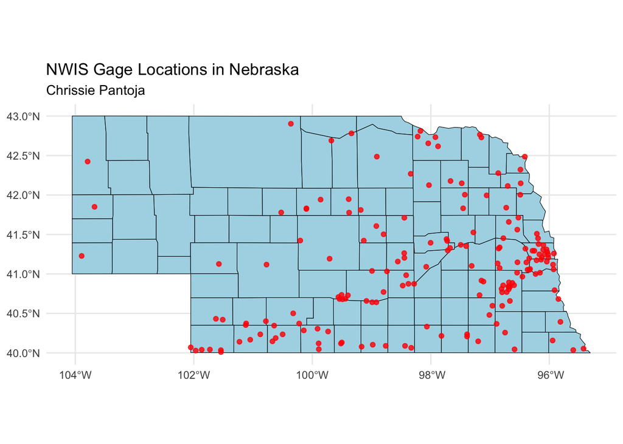

```r
# Plot counties and gage locations with further adjustments
ggplot() +
  # Plot the counties dataset (using the sf dataframe)
  geom_sf(data = nebraska_counties, fill = "lightblue", color = "black") +
  # Plot the gage locations with larger size and adjusted transparency
  geom_sf(data = nwis_sf, color = "red", size = 1.5, alpha = 0.8) +
  # Add title and subtitle
  ggtitle("NWIS Gage Locations in Nebraska", subtitle = "Chrissie Pantoja") +
  # Customize the theme
  theme_minimal() +
  # Adjust the map limits to focus the map on Nebraska
  coord_sf()  # Make sure the map zoom is appropriate
```

### Read in the gage height data and join the site location data to it.

Lastly, we want to attach some gage height data to our site locations. I’ve constructed a csv file listing many of the Nebraska gage sites, by station name and site number along with stream gage heights (in meters) recorded during the recent flood event. This file is titled `NWIS_SiteFlowData_NE_RAW.csv` and is found in the Data/Raw folder.

14. Read the `NWIS_SiteFlowData_NE_RAW.csv` dataset in as a dataframe
    - Pay attention to which fields should be imported as factors!

```r
# Read in the NWIS Site Flow Data CSV file
nwis_raw <- read.csv("Data/Raw/NWIS_SiteFlowData_NE_RAW.csv",
                        colClasses = (c("site_no"="factor")),
                                     stringsAsFactors = TRUE)
```

15. Show the column names.

```r
# Show the column names of the dataset
colnames(nwis_raw)
```

```
## [1] "site_no"    "station_nm" "date"       "gage_ht"
```

16. Join our site information (already imported above) to these gage height data
    - The `site_no` and `station_nm` can both/either serve as joining attributes
    - Construct this join so that the result only includes records features where both tables have data (N=136)

```r
sdf_gages_joined <- nwis_sf %>%
  inner_join(nwis_raw, by = "site_no")

# Perform the join using merge() and specifying the 'site_no' as the key for both datasets
gage_data_with_sites <- merge(
  x = nwis_sf,  # This is the raw gage height data
  y = nwis_raw,   # This is the site information spatial data
  by.x = "station_nm",  # The 'station_nm' column in the gage height data
  by.y = "station_nm",  # The 'station_nm' column in the site information data
  all = FALSE  # Ensures the join is an inner join (only matching records are kept)
)

# Check if the join resulted in 136 records
nrow(gage_data_with_sites)  # Should return 136
```

```
## [1] 136
```

17. Show the column names of this resulting spatial dataframe

```r
# Show the column names of the resulting spatial dataframe
colnames(gage_data_with_sites)
```

```
## [1] "station_nm"         "site_no.x"          "site_tp_cd"
## [4] "coord_acy_cd"       "dec_coord_datum_cd" "site_no.y"
## [7] "date"               "gage_ht"            "geometry"
```

18. Show the dimensions of the resulting joined dataframe

```r
# Show the dimensions (number of rows and columns) of the resulting joined dataframe
dim(gage_data_with_sites)
```

```
## [1] 136   9
```

### Map the pattern of gage height data

Now we can examine where the flooding appears most acute by visualizing gage heights spatially. 19. Plot the gage sites on top of counties (using `mapview`, `ggplot`, or `leaflet`) * Show the magnitude of gage height by color, shape, other visualization technique.

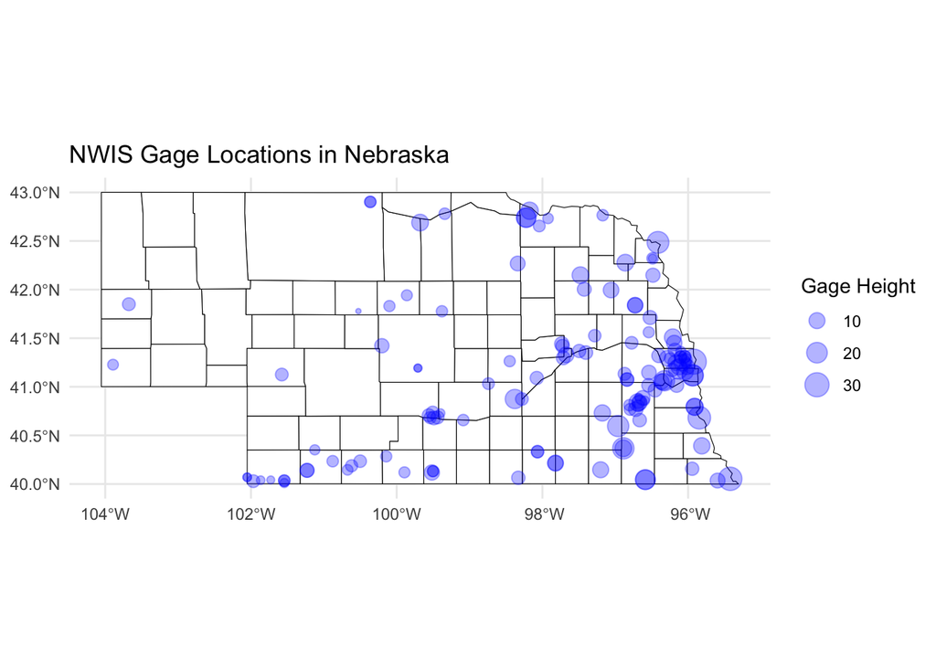

```r
# Plot counties and gage locations with further adjustments
ggplot() +
  # Plot the counties dataset (using the sf dataframe)
  geom_sf(data = nebraska_counties, fill = "white", color = "black") +
  # Plot the gage locations with larger size and adjusted transparency
  geom_sf(data = sdf_gages_joined, color = "blue", aes(size = gage_ht), alpha = 0.3) +
  # Add title and subtitle
  ggtitle("NWIS Gage Locations in Nebraska") +
  labs(size = "Gage Height")+
  # Customize the theme
  theme_minimal() +
  # Adjust the map limits to focus the map on Nebraska
  coord_sf()  # Make sure the map zoom is appropriate
```

## SPATIAL ANALYSIS

Up next we will do some spatial analysis with our data. To prepare for this, we should transform our data into a projected coordinate system. We’ll choose UTM Zone 14N (EPGS = 32614).

### Transform the counties and gage site datasets to UTM Zone 14N

20. Transform the counties and gage sf datasets to UTM Zone 14N (EPGS = 32614).

```r
# Transform counties to UTM Zone 14N (EPSG: 32614)
counties_sf_utm <- st_transform(nebraska_counties, crs = 32614)

# Transform gage sites to UTM Zone 14N (EPSG: 32614)
gage_data_utm <- st_transform(gage_data_with_sites, crs = 32614)
```

21. Using `mapview` or `ggplot`, plot the data so that each can be seen as different colors

```r
# Create interactive map with different colors for each layer
mapview(counties_sf_utm, col.regions = "blue") +
  mapview(gage_data_utm, col.regions = "red")
```

[interactive chart not shown]

### Select the gages falling within a given county

Now let’s zoom into a particular county and examine the gages located there. 22. Select Lancaster county from your projected county sf dataframe

```r
# Filter the county sf dataframe for Lancaster County
lancaster_county <- counties_sf_utm %>%
  filter(NAME == "Lancaster")
```

23. Select the gage sites falling within that county to a new spatial dataframe

```r
# Use st_intersection to find gage sites within Lancaster County
lancaster_gages <- st_intersection(gage_data_utm, lancaster_county)
```

24. Select the gage sites within 15km of the county to a new spatial dataframe

```r
# Create a 15 km buffer around Lancaster County
lancaster_buffer <- st_buffer(lancaster_county, dist = 15000)

# Select gage sites that intersect with the buffer
lancaster_gages_within_15km <- st_intersection(gage_data_utm, lancaster_buffer)
```

25. Create a plot showing (each symbolized distinctly):
- all Nebraska counties,
- the selected county,
- the gage sites in that county,
- and the gage sites within 15 km of the county

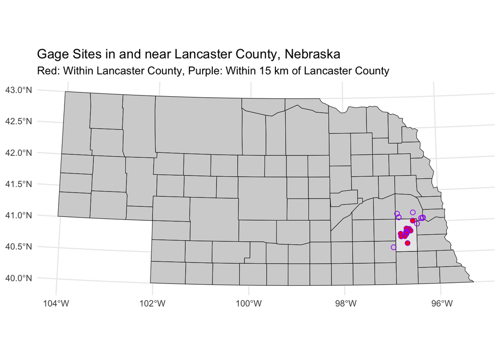

```r
# Plot the map
ggplot() +
  # Plot all counties in Nebraska with a light gray color
  geom_sf(data = counties_sf_utm, fill = "lightgray", color = "black") +

  # Highlight Lancaster County in a distinct color, such as blue
  geom_sf(data = lancaster_county, fill = "white", color = "black", alpha = 0.5) +

  # Plot gage sites within Lancaster County with a different symbol, such as filled circles
  geom_sf(data = lancaster_gages, color = "red", shape = 16, size = 2,
          show.legend = TRUE) +

  # Plot gage sites within 15 km of Lancaster County with another symbol, such as hollow circles
  geom_sf(data = lancaster_gages_within_15km, color = "purple", shape = 1, size = 2,
          show.legend = TRUE) +

  # Add a title and labels
  labs(title = "Gage Sites in and near Lancaster County, Nebraska",
       subtitle = "Red: Within Lancaster County, Purple: Within 15 km of Lancaster County") +

  # Set coordinate system
  coord_sf() +

  # Optional theme for clarity
  theme_minimal()
```